# Analysis Movie data by linear regression model

Lee kyu min Jang hyeng ook

date : 2018.11.22

- University : 한국외국어 대학교
- professor : 이태욱교수님

# 0. 데이터 및 패키지 로드

*출처: 영화산업진흥회

*필요 패키지 로드

```r
library(ggplot2)
library(dplyr)
library(tidyr)
library(data.table)
library(gridExtra)
library(MASS)
library(car)
library(randomForest)
```

*movie 데이터 읽어오기

```r
movie <- read.csv("C:/Users/user/Desktop/영화 데이터 최신(500).csv")
movie1 <- movie[,c("Audience","Audiencebox","Sales","Year","Screen","History","Action","Drama","Horor","Disaster","Comic","Erotic","Crime","Actorpower","Thousand","Factory")]
head(movie1)
```

```
##   Audience Audiencebox        Sales Year Screen History Action Drama Horor
## 1 17613682        4.09 136000000000   14   1587       1      1     0     0
## 2 14410931        4.09 116000000000   17   1912       0      1     1     0
## 3 14257115        4.09 111000000000   14    966       1      0     1     0
## 4 13414009        4.09 105000000000   15   1064       0      1     1     0
## 5 13019740        4.08  66716119300    6    167       0      1     0     0
## 6 12983330        4.08  93665568500   12   1072       0      1     1     0
##   Disaster Comic Erotic Crime Actorpower Thousand Factory
## 1        0     0      0     0         46        2       1
## 2        0     0      0     0         35        9       1
## 3        0     0      0     0         46        5       1
## 4        0     0      0     1         43        8       1
## 5        1     0      0     0         22        0       1
## 6        0     0      0     1         23        1       1
```

*———————————————————————————————

# 1. 변수 알아보기

## 1-1양적 설명변수간의 연관성있는지 상관계수로 알아보기

```r
quantmovie <- movie[,c("Year","Screen","Actorpower","Thousand")]
cor(quantmovie)
```

```
##                  Year     Screen Actorpower  Thousand
## Year       1.00000000 0.85377837 0.01780342 0.3871747
## Screen     0.85377837 1.00000000 0.09972819 0.5497567
## Actorpower 0.01780342 0.09972819 1.00000000 0.1250046
## Thousand   0.38717468 0.54975665 0.12500459 1.0000000
```

```r
cor <- cor(quantmovie)>0.5
cor
```

```
##             Year Screen Actorpower Thousand
## Year        TRUE   TRUE      FALSE    FALSE
## Screen      TRUE   TRUE      FALSE     TRUE
## Actorpower FALSE  FALSE       TRUE    FALSE
## Thousand   FALSE   TRUE      FALSE     TRUE
```

```r
###0.5이상인것만 따로확인
movie2 <- movie1[,c("Year","Screen","Thousand","Screen")]
cor(movie2)
```

```
##               Year    Screen  Thousand  Screen.1
## Year     1.0000000 0.8537784 0.3871747 0.8537784
## Screen   0.8537784 1.0000000 0.5497567 1.0000000
## Thousand 0.3871747 0.5497567 1.0000000 0.5497567
## Screen.1 0.8537784 1.0000000 0.5497567 1.0000000
```

## 1-2질적 설명변수 알아보기

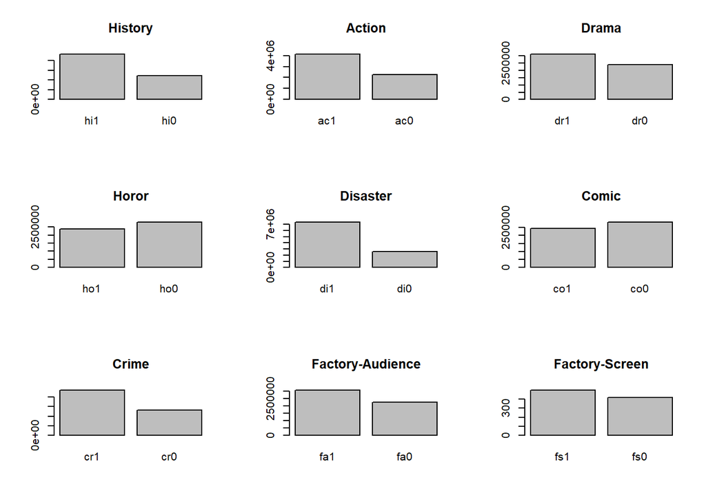

```r
par(mfrow = c(3,3))
###History
Historyo <- filter(movie1,History==1)
Historyx <- filter(movie1,History==0)
hi1 <- mean(Historyo$Audience)
hi0 <- mean(Historyx$Audience)
hi <- barplot(c(hi1,hi0),names=c("hi1","hi0"),main="History")
##Action
Actiono <- filter(movie1,Action==1)
Actionx <- filter(movie1,Action==0)
ac1 <- mean(Actiono$Audience)
ac0 <- mean(Actionx$Audience)
ac <- barplot(c(ac1,ac0),names=c("ac1","ac0"),main="Action")
##Drama
Dramao <- filter(movie1,Drama==1)
Dramax <- filter(movie1,Drama==0)
dr1 <- mean(Dramao$Audience)
dr0 <- mean(Dramax$Audience)
dr <- barplot(c(dr1,dr0),names=c("dr1","dr0"),main="Drama")
##Horor
Hororo <- filter(movie1,Horor==1)
Hororx <- filter(movie1,Horor==0)
ho1 <- mean(Hororo$Audience)
ho0 <- mean(Hororx$Audience)
ho <- barplot(c(ho1,ho0),names=c("ho1","ho0"),main="Horor")
##Disaster
Disastero <- filter(movie1,Disaster==1)
Disasterx <- filter(movie1,Disaster==0)
di1 <- mean(Disastero$Audience)
di0 <- mean(Disasterx$Audience)
di <- barplot(c(di1,di0),names=c("di1","di0"),main="Disaster")
##Comic
Comico <- filter(movie1,Comic==1)
Comicx <- filter(movie1,Comic==0)
co1 <- mean(Comico$Audience)
co0 <- mean(Comicx$Audience)
co <- barplot(c(co1,co0),names=c("co1","co0"),main="Comic")
##Crime
Crimeo <- filter(movie1,Crime==1)
Crimex <- filter(movie1,Crime==0)
cr1 <- mean(Crimeo$Audience)
cr0 <- mean(Crimex$Audience)
cr <- barplot(c(cr1,cr0),names=c("cr1","cr0"),main="Crime")
##Factory1
Factoryo <- filter(movie1,Factory==1)
Factoryx <- filter(movie1,Factory==0)
fa1 <- mean(Factoryo$Audience)
fa0 <- mean(Factoryx$Audience)
fa <- barplot(c(fa1,fa0),names=c("fa1","fa0"),main="Factory-Audience")
##Factory2
Factoryo <- filter(movie1,Factory==1)
Factoryx <- filter(movie1,Factory==0)
fs1 <- mean(Factoryo$Screen)
fs0 <- mean(Factoryx$Screen)
fs <- barplot(c(fs1,fs0),names=c("fs1","fs0"),main="Factory-Screen")
```

**장르부문에서 Horor(공포)와 Comic(코믹)은 관객 수에 악영향을 끼치는 것으로 보이고

**영화가 disaster(재난) 요소를 포함하는지 않하는지에 가장 큰 차이를 보인다.

*———————————————————————————————

# 2. Regression model

## 2-1 All data

```r
reg <- lm(Audience ~ Year+Screen+History+Action+Drama+Horor+Disaster+Comic+Erotic+Crime+Actorpower+Thousand+Factory, data=movie1)
summary(reg)
```

```
##
## Call:
## lm(formula = Audience ~ Year + Screen + History + Action + Drama +
##     Horor + Disaster + Comic + Erotic + Crime + Actorpower +
##     Thousand + Factory, data = movie1)
##
## Residuals:
##      Min       1Q   Median       3Q      Max
## -4979504  -802717  -219213   441098  8926697
##
## Coefficients:
##              Estimate Std. Error t value Pr(>|t|)
## (Intercept) -590916.5   404782.8  -1.460 0.144981
## Year        -227708.4    31631.2  -7.199 2.32e-12 ***
## Screen         3666.5      436.3   8.404 4.81e-16 ***
## History     2400598.7   263514.6   9.110  < 2e-16 ***
## Action      2338518.6   234693.4   9.964  < 2e-16 ***
## Drama       2406879.3   218397.2  11.021  < 2e-16 ***
## Horor       2042511.2   309601.6   6.597 1.10e-10 ***
## Disaster    3588427.2   473811.0   7.574 1.85e-13 ***
## Comic       1831692.4   233106.9   7.858 2.53e-14 ***
## Erotic       731100.1   702962.9   1.040 0.298845
## Crime       1059940.0   328406.3   3.228 0.001333 **
## Actorpower    25271.5     9712.3   2.602 0.009551 **
## Thousand     214180.2    60258.9   3.554 0.000416 ***
## Factory      317120.3   158373.4   2.002 0.045801 *
## ---
## Signif. codes:  0 '***' 0.001 '**' 0.01 '*' 0.05 '.' 0.1 ' ' 1
##
## Residual standard error: 1694000 on 486 degrees of freedom
## Multiple R-squared:  0.5911, Adjusted R-squared:  0.5802
## F-statistic: 54.04 on 13 and 486 DF,  p-value: < 2.2e-16
```

### 2-1-1유의한 경우만 사용한경우 (Erotic 변수 제거)

```r
preg <- lm(Audience ~ Year+Screen+History+Action+Drama+Horor+Disaster+Comic+Crime+Actorpower+Thousand+Factory, data=movie1)
summary(preg)
```

```
##
## Call:
## lm(formula = Audience ~ Year + Screen + History + Action + Drama +
##     Horor + Disaster + Comic + Crime + Actorpower + Thousand +
##     Factory, data = movie1)
##
## Residuals:
##      Min       1Q   Median       3Q      Max
## -4957394  -805619  -229113   482496  8904404
##
## Coefficients:
##              Estimate Std. Error t value Pr(>|t|)
## (Intercept) -566603.7   404141.1  -1.402 0.161554
## Year        -228581.1    31622.7  -7.228 1.90e-12 ***
## Screen         3678.5      436.2   8.433 3.84e-16 ***
## History     2407092.7   263462.7   9.136  < 2e-16 ***
## Action      2314112.1   233536.8   9.909  < 2e-16 ***
## Drama       2389354.6   217764.4  10.972  < 2e-16 ***
## Horor       2019955.6   308867.0   6.540 1.56e-10 ***
## Disaster    3578527.2   473755.1   7.554 2.11e-13 ***
## Comic       1826528.5   233073.6   7.837 2.93e-14 ***
## Crime       1057063.7   328422.2   3.219 0.001374 **
## Actorpower    25265.7     9713.1   2.601 0.009573 **
## Thousand     214607.8    60262.6   3.561 0.000405 ***
## Factory      325625.7   158175.4   2.059 0.040060 *
## ---
## Signif. codes:  0 '***' 0.001 '**' 0.01 '*' 0.05 '.' 0.1 ' ' 1
##
## Residual standard error: 1694000 on 487 degrees of freedom
## Multiple R-squared:  0.5902, Adjusted R-squared:  0.5801
## F-statistic: 58.45 on 12 and 487 DF,  p-value: < 2.2e-16
```

*다중공산성

```r
vif(preg)
```

```
##       Year     Screen    History     Action      Drama      Horor
##   4.305375   5.575208   1.349280   1.854495   2.058197   1.574431
##   Disaster      Comic      Crime Actorpower   Thousand    Factory
##   1.063823   1.547430   1.092438   1.070676   1.531712   1.040361
```

** VIF<10 을 만족하므로 공선성의 문제는 없다.

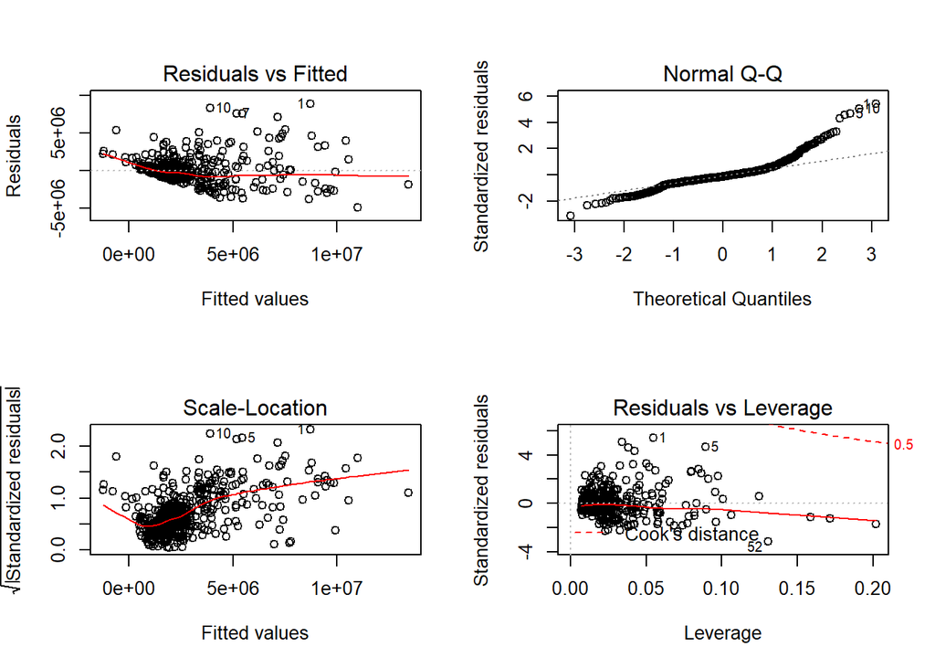

```r
par(mfrow=c(2,2))
plot(preg)
```

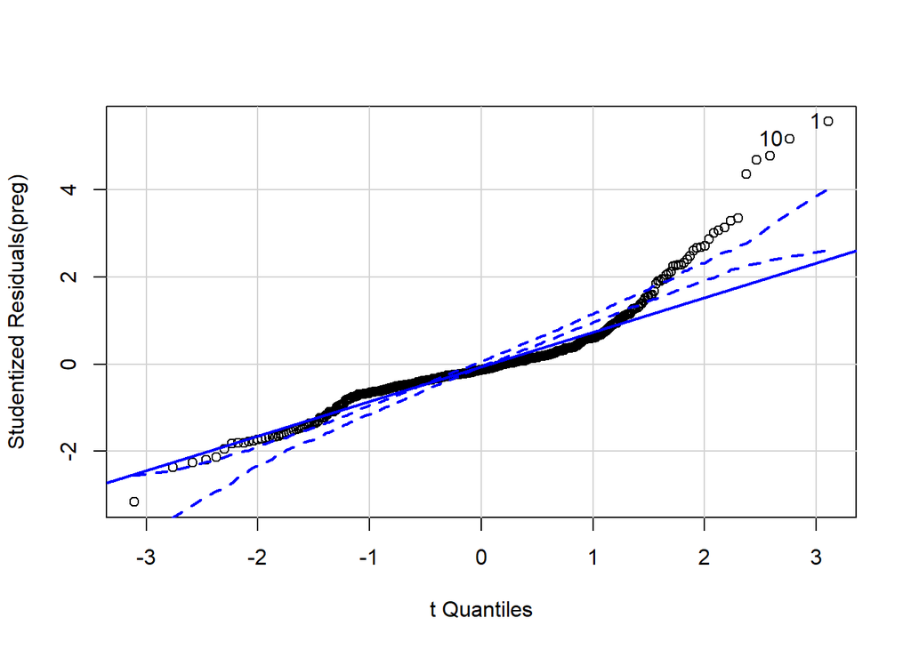

```
## [1]  1 10
```

```r
qqPlot(preg)
```

## 2-2 Over 2005

```r
movie2 <- filter(movie1, Year>5)
rreg <- lm(Audience ~ Year+Screen+History+Action+Drama+Horor+Disaster+Comic+Erotic+Crime+Actorpower+Thousand+Factory, data=movie2)
summary(rreg)
```

```
##
## Call:
## lm(formula = Audience ~ Year + Screen + History + Action + Drama +
##     Horor + Disaster + Comic + Erotic + Crime + Actorpower +
##     Thousand + Factory, data = movie2)
##
## Residuals:
##      Min       1Q   Median       3Q      Max
## -4196594  -830046  -219995   527075  8676372
##
## Coefficients:
##              Estimate Std. Error t value Pr(>|t|)
## (Intercept)  834216.5   583685.6   1.429  0.15380
## Year        -362105.3    45810.7  -7.904 3.28e-14 ***
## Screen         4835.1      507.3   9.530  < 2e-16 ***
## History     1968677.7   310287.4   6.345 6.66e-10 ***
## Action      1839022.5   282182.7   6.517 2.41e-10 ***
## Drama       2200305.1   257085.8   8.559 3.30e-16 ***
## Horor       1656624.8   366997.3   4.514 8.62e-06 ***
## Disaster    3389391.5   483622.8   7.008 1.19e-11 ***
## Comic       1926882.1   272520.1   7.071 8.00e-12 ***
## Erotic       190984.4   782535.9   0.244  0.80732
## Crime       1010299.7   359271.2   2.812  0.00519 **
## Actorpower    23583.1    11316.9   2.084  0.03787 *
## Thousand     216174.1    61640.5   3.507  0.00051 ***
## Factory      174428.3   194623.9   0.896  0.37072
## ---
## Signif. codes:  0 '***' 0.001 '**' 0.01 '*' 0.05 '.' 0.1 ' ' 1
##
## Residual standard error: 1717000 on 362 degrees of freedom
## Multiple R-squared:  0.6306, Adjusted R-squared:  0.6174
## F-statistic: 47.54 on 13 and 362 DF,  p-value: < 2.2e-16
```

### 2-2-1 유의한것만사용 (Erotic/Factory 변수 제거)

```r
prreg <- lm(Audience ~ Year+Screen+History+Action+Drama+Horor+Disaster+Comic+Crime+Actorpower+Thousand, data=movie2)
summary(prreg)
```

```
##
## Call:
## lm(formula = Audience ~ Year + Screen + History + Action + Drama +
##     Horor + Disaster + Comic + Crime + Actorpower + Thousand,
##     data = movie2)
##
## Residuals:
##      Min       1Q   Median       3Q      Max
## -4314899  -807306  -229212   492443  8679328
##
## Coefficients:
##              Estimate Std. Error t value Pr(>|t|)
## (Intercept)  977495.4   562238.4   1.739 0.082955 .
## Year        -368523.8    45220.4  -8.150 5.94e-15 ***
## Screen         4856.8      505.9   9.600  < 2e-16 ***
## History     1994784.7   308528.0   6.465 3.25e-10 ***
## Action      1840588.6   280037.2   6.573 1.71e-10 ***
## Drama       2202683.3   255833.8   8.610 2.24e-16 ***
## Horor       1645656.6   365437.0   4.503 9.02e-06 ***
## Disaster    3385053.7   482747.7   7.012 1.15e-11 ***
## Comic       1943666.7   271160.7   7.168 4.27e-12 ***
## Crime       1010341.6   358690.1   2.817 0.005116 **
## Actorpower    24610.0    11245.7   2.188 0.029275 *
## Thousand     220535.2    61362.9   3.594 0.000371 ***
## ---
## Signif. codes:  0 '***' 0.001 '**' 0.01 '*' 0.05 '.' 0.1 ' ' 1
##
## Residual standard error: 1715000 on 364 degrees of freedom
## Multiple R-squared:  0.6297, Adjusted R-squared:  0.6186
## F-statistic: 56.28 on 11 and 364 DF,  p-value: < 2.2e-16
```

```r
vif(prreg)
```

```
##       Year     Screen    History     Action      Drama      Horor
##   3.527040   4.872182   1.450835   2.041964   2.091777   1.623697
##   Disaster      Comic      Crime Actorpower   Thousand
##   1.068458   1.311653   1.096752   1.070979   1.467460
```

**Vif<10이므로 다중공선성 문제 없다.

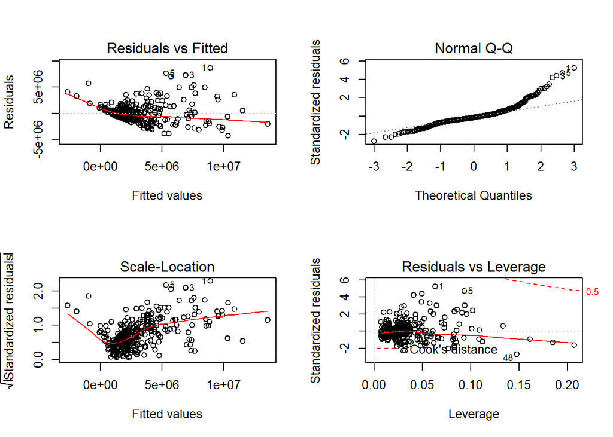

```r
par(mfrow=c(2,2))
plot(prreg)
```

## 2-3 Over 2010

```r
movie3 <- filter(movie1, Year>10)
rrreg <- lm(Audience ~ Year+Screen+History+Action+Drama+Horor+Disaster+Comic+Erotic+Crime+Actorpower+Thousand+Factory, data=movie3)
summary(rrreg)
```

```
##
## Call:
## lm(formula = Audience ~ Year + Screen + History + Action + Drama +
##     Horor + Disaster + Comic + Erotic + Crime + Actorpower +
##     Thousand + Factory, data = movie3)
##
## Residuals:
##      Min       1Q   Median       3Q      Max
## -4149824  -948627  -237286   659038  7996102
##
## Coefficients:
##              Estimate Std. Error t value Pr(>|t|)
## (Intercept) 3098534.3  1048191.1   2.956  0.00345 **
## Year        -530326.0    72697.1  -7.295 5.17e-12 ***
## Screen         5140.9      608.5   8.448 3.82e-15 ***
## History     2273072.6   404415.1   5.621 5.65e-08 ***
## Action      1838153.3   389693.5   4.717 4.22e-06 ***
## Drama       2292359.8   343022.9   6.683 1.85e-10 ***
## Horor       1952794.0   476830.5   4.095 5.90e-05 ***
## Disaster    1678495.9   579957.9   2.894  0.00418 **
## Comic       1887092.3   373459.2   5.053 9.05e-07 ***
## Erotic      -605588.2  1298324.1  -0.466  0.64136
## Crime       1002836.7   440520.1   2.276  0.02377 *
## Actorpower    28059.2    14907.6   1.882  0.06111 .
## Thousand     252169.7    68475.6   3.683  0.00029 ***
## Factory     -121281.7   262117.2  -0.463  0.64403
## ---
## Signif. codes:  0 '***' 0.001 '**' 0.01 '*' 0.05 '.' 0.1 ' ' 1
##
## Residual standard error: 1807000 on 223 degrees of freedom
## Multiple R-squared:  0.6743, Adjusted R-squared:  0.6553
## F-statistic: 35.51 on 13 and 223 DF,  p-value: < 2.2e-16
```

### 2-3-1 유의한것만 사용(Erotic/Factory 제거)

```r
prrreg <- lm(Audience ~ Year+Screen+History+Action+Drama+Horor+Disaster+Comic+Crime+Actorpower+Thousand, data=movie3)
summary(prrreg)
```

```
##
## Call:
## lm(formula = Audience ~ Year + Screen + History + Action + Drama +
##     Horor + Disaster + Comic + Crime + Actorpower + Thousand,
##     data = movie3)
##
## Residuals:
##      Min       1Q   Median       3Q      Max
## -4169728  -969719  -202911   614366  8001976
##
## Coefficients:
##              Estimate Std. Error t value Pr(>|t|)
## (Intercept) 2936732.5   987303.0   2.974 0.003255 **
## Year        -521518.5    70171.4  -7.432 2.21e-12 ***
## Screen         5108.1      604.3   8.454 3.57e-15 ***
## History     2272846.4   400645.0   5.673 4.29e-08 ***
## Action      1863608.6   386302.0   4.824 2.59e-06 ***
## Drama       2299455.9   341497.8   6.733 1.36e-10 ***
## Horor       1974918.9   473925.5   4.167 4.40e-05 ***
## Disaster    1706040.4   576284.5   2.960 0.003401 **
## Comic       1889523.1   371185.5   5.091 7.54e-07 ***
## Crime       1008170.9   438652.4   2.298 0.022461 *
## Actorpower    26932.5    14711.6   1.831 0.068468 .
## Thousand     247160.9    67632.9   3.654 0.000321 ***
## ---
## Signif. codes:  0 '***' 0.001 '**' 0.01 '*' 0.05 '.' 0.1 ' ' 1
##
## Residual standard error: 1801000 on 225 degrees of freedom
## Multiple R-squared:  0.6737, Adjusted R-squared:  0.6577
## F-statistic: 42.22 on 11 and 225 DF,  p-value: < 2.2e-16
```

```r
vif(prrreg)
```

```
##       Year     Screen    History     Action      Drama      Horor
##   1.795950   3.008569   1.511093   2.288199   2.130180   1.656824
##   Disaster      Comic      Crime Actorpower   Thousand
##   1.074109   1.175870   1.086436   1.114654   1.428130
```

**Vif<10이므로 다중공선성 문제 없다.

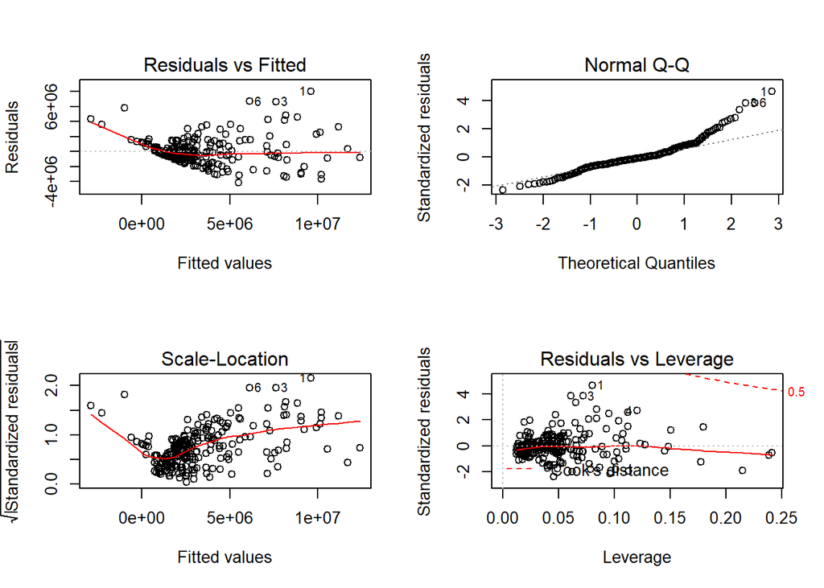

```r
par(mfrow=c(2,2))
plot(prrreg)
```

*———————————————————————————————

# 3. 세가지 모델의 비교

*———————————————————————————————

# 4. 가장 좋은 model 찾기

*1.안시성: 관객 5,436,779 연도18 스크린수1538 사극/액션 배우파워3+3+19=25 천만0+0+1 배급사X

**전체모델 : 6,566,602 (오차:-1,129,823)

**2005이후모델: 6,476,120 (오차:-1,039,341)

**2010이후모델: 6,494,779 (오차:-1,057,990)

*2.협상: 관객 1,743,437 연도18 스크린수918 범죄 배급사CJ 배우파워6+4+16=26 천만3

**전체모델 : 1,313,437 (오차:-430,000)

**2005이후모델: 1,122,617 (오차:+620,820)

**2010이후모델: 689,904 (오차:+1,053,533)

*3.명당: 관객 1,968,493 연도 18 스크린수1,114 역사 배급사X 배우파워5+4+13=22 천만1

**전체모델 : 2,615,714 (오차:+647,221)

**2005이후모델: 2,512,191 (오차:+543,698)

**2010이후모델: 2,378,229 (오차:+409,736)

*4.독전: 관객 5,063,620 연도18 스크린1532 범죄, 액션 배우파워 20+10+16=46 천만3 배급사x

**전체모델 : 6,068,023 (오차: 1,004,403)

**2005이후모델 : 6,417,487 (오차: 1,353,849)

**2010이후모델 : 6,198,437 (오차: 1,134,817)

*5.원더풀고스트: 관객449,906 연도18 스크린수351 범죄 코미디 배우파워21+5+6=32 천만3 배급사X

**전체모델 : 887,781 (오차:-437,875)

**2005이후모델: 447,612 (오차:-2,294)

**2010이후모델: 236,884 (오차:+213,022)

*6.암수살인: 관객3,739,085 연도18 스크린1177 범죄 드라마 배우파워9+9+9=27 천만3 배급O

**전체모델 : 4,677,356 (오차:-938,271)

**2005이후모델: 4,600,509 (오차:-861,424)

**2010이후모델: 4,329,550 (오차:-590,465)

*7.창궐: 관객1,596,687 연도18 스크린1351 액션 배우파워25 천만0 배급사x

**전체모델 : 3,257,099 (오차:-1,660,412)

**2005이후모델: 3,349,064 (오차:-1,752,377)

**2010이후모델: 2,988,993 (오차:-1,392,306)

*8.미쓰백: 관객721,204 연도18 스크린638 드라마 배우파워7+0+20 천만x 배급사x

**전체모델 : 756,680 (오차:+35,476)

**2005이후모델: 300,853 (오차:-420,351)

**2010이후모델: -196,915 (오차:-918,119)

*9.완벽한타인: 관객4,427,723 연도18 스크린1313 코미디 배우파워28+22+2=52 천만5 배급사o

**전체모델 : 4,701,327 (오차: +273,604)

**2005이후모델: 5,058,675 (오차: +630,952)

**2010이후모델: 4,799,100 (오차: +371,377)

## 4-1 Using MSE (단위: 만)

```r
sse1 <- 113^2+43^2+65^2+100^2+43^2+94^2+166^2+4^2+27^2
mse1 <- sqrt(sse1/9)

sse2 <- 104^2+62^2+54^2+135^2+0.2^2+86^2+175^2+42^2+63^2
mse2 <- sqrt(sse2/9)

sse3 <- 106^2+105^2+41^2+113^2+21^2+59^2+139^2+92^2+37^2
mse3 <- sqrt(sse3/9)

a <- c("Total MSE",mse1)
b <- c("Over 2005 MSE",mse2)
c <- c("Over 2010 MSE",mse3)
MSE <- data.frame(a,b,c)
MSE
```

```
##                  a                b                c
## 1        Total MSE    Over 2005 MSE    Over 2010 MSE
## 2 86.8133374289663 94.0183433638824 88.0574307546564
```

**MSE 측면에서 Total model이 가장 우수하다!

## 4-2 Using MAPE

```r
m1 <- c(1129823/5436779,430000/1743437,647221/1968493,1004403/5063620,437875/449906,938271/3739085,1660412/1596687,35476/721204, 273604/4427723)
mape1 <- median(m1)

m2 <- c(1039341/5436779,620820/1743437,543698/1968493,1353849/5063620,2294/449906,861424/3739085,1752377/1596687,420351/721204,630952/4427723)
mape2 <- median(m2)

m3 <- c(1057990/5436779,1053533/1743437,409736/1968493,1134817/5063620,213022/449906,590465/3739085,1392306/1596687,918119/721204,371377/4427723)
mape3 <- median(m3)

d <- c("Total MAPE",mape1)
e <- c("Over 2005 MAPE",mape2)
f <- c("Over 2010 MAPE",mape3)
MAPE <- data.frame(d,e,f)
MAPE
```

```
##                   d                 e                 f
## 1        Total MAPE    Over 2005 MAPE    Over 2010 MAPE
## 2 0.246639253382829 0.267367811960613 0.224111801438497
```

**MAPE 측면에서 Over2010 model이 가장 우수하다!** 이때 영화데이터는 이상치가 크므로 Mean 대신 Median을 사용 하였다.

*—————————————————————

# 5. BOX-CoX변환

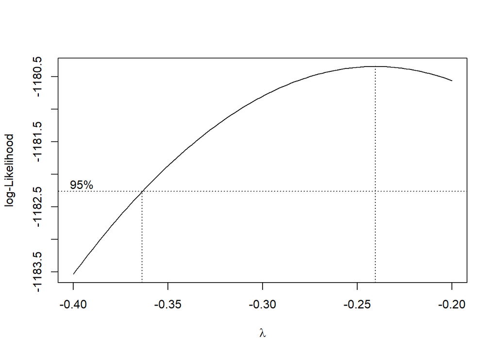

```r
###정규성 만족을 시키기 위해 BOX-CoX변환
bc <- boxcox(Audience~Year+Screen+History+Action+Drama+Horor+Disaster+Comic+Erotic+Crime+Actorpower+Thousand+Factory, data= movie1,lambda=seq(-0.4,-0.2,0.01))
```

```r
bc
```

[output not shown]

[output cut: 20 more lines]

**lambda=-0.24

### 5-1 box-cox total

```r
breg <- lm(Audiencebox ~ Year+Screen+History+Action+Drama+Horor+Disaster+Comic+Erotic+Crime+Actorpower+Thousand+Factory, data=movie1)
summary(breg)
```

```
##
## Call:
## lm(formula = Audiencebox ~ Year + Screen + History + Action +
##     Drama + Horor + Disaster + Comic + Erotic + Crime + Actorpower +
##     Thousand + Factory, data = movie1)
##
## Residuals:
##       Min        1Q    Median        3Q       Max
## -0.040515 -0.010819 -0.000203  0.008234  0.054527
##
## Coefficients:
##               Estimate Std. Error  t value Pr(>|t|)
## (Intercept)  4.005e+00  3.538e-03 1131.928  < 2e-16 ***
## Year        -1.538e-03  2.765e-04   -5.563 4.38e-08 ***
## Screen       2.610e-05  3.814e-06    6.843 2.35e-11 ***
## History      1.526e-02  2.303e-03    6.626 9.16e-11 ***
## Action       1.666e-02  2.052e-03    8.122 3.82e-15 ***
## Drama        1.595e-02  1.909e-03    8.356 6.85e-16 ***
## Horor        1.304e-02  2.706e-03    4.818 1.94e-06 ***
## Disaster     2.604e-02  4.142e-03    6.287 7.21e-10 ***
## Comic        8.249e-03  2.038e-03    4.048 6.01e-05 ***
## Erotic       1.626e-02  6.145e-03    2.645  0.00842 **
## Crime        1.176e-02  2.871e-03    4.095 4.94e-05 ***
## Actorpower   4.787e-04  8.490e-05    5.638 2.91e-08 ***
## Thousand     7.535e-04  5.267e-04    1.430  0.15322
## Factory      4.100e-03  1.384e-03    2.962  0.00321 **
## ---
## Signif. codes:  0 '***' 0.001 '**' 0.01 '*' 0.05 '.' 0.1 ' ' 1
##
## Residual standard error: 0.01481 on 486 degrees of freedom
## Multiple R-squared:  0.515,  Adjusted R-squared:  0.502
## F-statistic: 39.69 on 13 and 486 DF,  p-value: < 2.2e-16
```

```r
###유의한것만 이용
bpreg <- lm(Audiencebox ~ Year+Screen+History+Action+Drama+Horor+Disaster+Comic+Erotic+Crime+Actorpower+Factory, data=movie1)
summary(bpreg)
```

```
##
## Call:
## lm(formula = Audiencebox ~ Year + Screen + History + Action +
##     Drama + Horor + Disaster + Comic + Erotic + Crime + Actorpower +
##     Factory, data = movie1)
##
## Residuals:
##       Min        1Q    Median        3Q       Max
## -0.040720 -0.010688 -0.000364  0.008518  0.055147
##
## Coefficients:
##               Estimate Std. Error  t value Pr(>|t|)
## (Intercept)  4.005e+00  3.523e-03 1136.863  < 2e-16 ***
## Year        -1.592e-03  2.743e-04   -5.803 1.17e-08 ***
## Screen       2.809e-05  3.555e-06    7.900 1.87e-14 ***
## History      1.564e-02  2.291e-03    6.828 2.57e-11 ***
## Action       1.689e-02  2.048e-03    8.248 1.51e-15 ***
## Drama        1.619e-02  1.904e-03    8.507  < 2e-16 ***
## Horor        1.328e-02  2.704e-03    4.911 1.24e-06 ***
## Disaster     2.630e-02  4.142e-03    6.350 4.93e-10 ***
## Comic        8.533e-03  2.030e-03    4.203 3.13e-05 ***
## Erotic       1.632e-02  6.151e-03    2.652  0.00825 **
## Crime        1.192e-02  2.872e-03    4.149 3.94e-05 ***
## Actorpower   4.866e-04  8.481e-05    5.737 1.69e-08 ***
## Factory      4.218e-03  1.383e-03    3.049  0.00242 **
## ---
## Signif. codes:  0 '***' 0.001 '**' 0.01 '*' 0.05 '.' 0.1 ' ' 1
##
## Residual standard error: 0.01483 on 487 degrees of freedom
## Multiple R-squared:  0.5129, Adjusted R-squared:  0.5009
## F-statistic: 42.74 on 12 and 487 DF,  p-value: < 2.2e-16
```

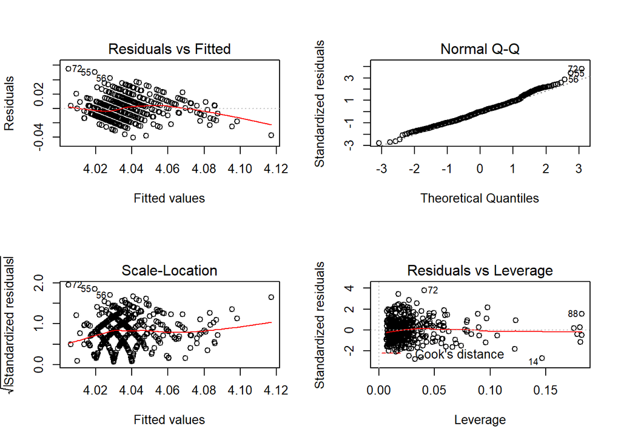

```r
par(mfrow=c(2,2))
plot(bpreg)
```

### 5-2 box-cox 2005

```r
brreg <- lm(Audiencebox ~ Year+Screen+History+Action+Drama+Horor+Disaster+Comic+Erotic+Crime+Actorpower+Thousand+Factory, data=movie2)
summary(brreg)
```

```
##
## Call:
## lm(formula = Audiencebox ~ Year + Screen + History + Action +
##     Drama + Horor + Disaster + Comic + Erotic + Crime + Actorpower +
##     Thousand + Factory, data = movie2)
##
## Residuals:
##       Min        1Q    Median        3Q       Max
## -0.037378 -0.010379 -0.000630  0.009449  0.056076
##
## Coefficients:
##               Estimate Std. Error t value Pr(>|t|)
## (Intercept)  4.017e+00  5.026e-03 799.250  < 2e-16 ***
## Year        -2.539e-03  3.945e-04  -6.435 3.92e-10 ***
## Screen       3.522e-05  4.369e-06   8.060 1.12e-14 ***
## History      1.303e-02  2.672e-03   4.875 1.63e-06 ***
## Action       1.295e-02  2.430e-03   5.329 1.74e-07 ***
## Drama        1.438e-02  2.214e-03   6.496 2.73e-10 ***
## Horor        1.010e-02  3.160e-03   3.196 0.001515 **
## Disaster     2.437e-02  4.165e-03   5.853 1.08e-08 ***
## Comic        9.341e-03  2.347e-03   3.980 8.32e-05 ***
## Erotic       1.050e-02  6.739e-03   1.558 0.120119
## Crime        1.037e-02  3.094e-03   3.351 0.000891 ***
## Actorpower   4.050e-04  9.746e-05   4.156 4.05e-05 ***
## Thousand     7.570e-04  5.308e-04   1.426 0.154691
## Factory      2.513e-03  1.676e-03   1.499 0.134724
## ---
## Signif. codes:  0 '***' 0.001 '**' 0.01 '*' 0.05 '.' 0.1 ' ' 1
##
## Residual standard error: 0.01479 on 362 degrees of freedom
## Multiple R-squared:  0.547,  Adjusted R-squared:  0.5307
## F-statistic: 33.62 on 13 and 362 DF,  p-value: < 2.2e-16
```

```r
###유의한변수만이용
bprreg <- lm(Audiencebox ~ Year+Screen+History+Action+Drama+Horor+Disaster+Comic+Crime+Actorpower, data=movie2)
summary(bprreg)
```

```
##
## Call:
## lm(formula = Audiencebox ~ Year + Screen + History + Action +
##     Drama + Horor + Disaster + Comic + Crime + Actorpower, data = movie2)
##
## Residuals:
##       Min        1Q    Median        3Q       Max
## -0.039081 -0.010971 -0.000805  0.010146  0.055992
##
## Coefficients:
##               Estimate Std. Error t value Pr(>|t|)
## (Intercept)  4.019e+00  4.854e-03 828.042  < 2e-16 ***
## Year        -2.708e-03  3.906e-04  -6.932 1.89e-11 ***
## Screen       3.786e-05  4.158e-06   9.107  < 2e-16 ***
## History      1.406e-02  2.652e-03   5.302 1.99e-07 ***
## Action       1.298e-02  2.422e-03   5.361 1.47e-07 ***
## Drama        1.456e-02  2.208e-03   6.594 1.50e-10 ***
## Horor        1.002e-02  3.163e-03   3.167 0.001669 **
## Disaster     2.452e-02  4.183e-03   5.862 1.02e-08 ***
## Comic        9.880e-03  2.340e-03   4.223 3.05e-05 ***
## Crime        1.048e-02  3.110e-03   3.369 0.000836 ***
## Actorpower   4.358e-04  9.722e-05   4.482 9.90e-06 ***
## ---
## Signif. codes:  0 '***' 0.001 '**' 0.01 '*' 0.05 '.' 0.1 ' ' 1
##
## Residual standard error: 0.01487 on 365 degrees of freedom
## Multiple R-squared:  0.538,  Adjusted R-squared:  0.5253
## F-statistic:  42.5 on 10 and 365 DF,  p-value: < 2.2e-16
```

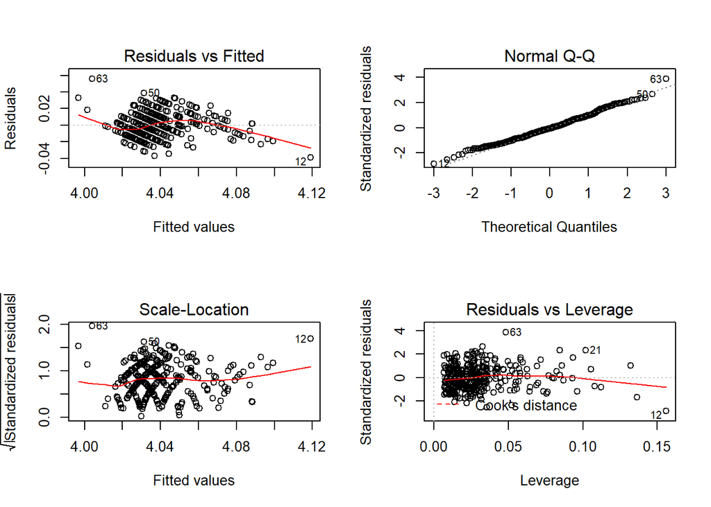

```r
par(mfrow=c(2,2))
plot(bprreg)
```

### 5-3 box-cox 2010

```r
bprrreg <- lm(Audiencebox ~ Year+Screen+History+Action+Drama+Horor+Disaster+Comic+Crime+Actorpower+Thousand, data=movie3)
summary(bprrreg)
```

```
##
## Call:
## lm(formula = Audiencebox ~ Year + Screen + History + Action +
##     Drama + Horor + Disaster + Comic + Crime + Actorpower + Thousand,
##     data = movie3)
##
## Residuals:
##       Min        1Q    Median        3Q       Max
## -0.027701 -0.011735 -0.000491  0.010302  0.053355
##
## Coefficients:
##               Estimate Std. Error t value Pr(>|t|)
## (Intercept)  4.037e+00  8.057e-03 501.108  < 2e-16 ***
## Year        -3.670e-03  5.726e-04  -6.409 8.50e-10 ***
## Screen       3.865e-05  4.931e-06   7.837 1.82e-13 ***
## History      1.131e-02  3.270e-03   3.460 0.000647 ***
## Action       1.038e-02  3.152e-03   3.292 0.001153 **
## Drama        1.230e-02  2.787e-03   4.415 1.57e-05 ***
## Horor        1.018e-02  3.868e-03   2.632 0.009068 **
## Disaster     1.652e-02  4.703e-03   3.512 0.000537 ***
## Comic        9.274e-03  3.029e-03   3.062 0.002469 **
## Crime        9.138e-03  3.580e-03   2.553 0.011345 *
## Actorpower   3.394e-04  1.201e-04   2.827 0.005119 **
## Thousand     9.234e-04  5.519e-04   1.673 0.095704 .
## ---
## Signif. codes:  0 '***' 0.001 '**' 0.01 '*' 0.05 '.' 0.1 ' ' 1
##
## Residual standard error: 0.0147 on 225 degrees of freedom
## Multiple R-squared:  0.5866, Adjusted R-squared:  0.5664
## F-statistic: 29.03 on 11 and 225 DF,  p-value: < 2.2e-16
```

[figure not shown]

```r
par(mfrow=c(2,2))
plot(bprreg)
```

**Box-Cox 변환을 하면 정규성 만족한다.

*———————————————————————————————

# 6. Machine learning

```r
movie99 <- read.csv("C:/Users/user/Desktop/traindata.csv")
movie99_classifier = randomForest(Audience~., data=movie99, importance=TRUE)
testdata <- read.csv("C:/Users/user/Desktop/testdata.csv")
predictedtable=predict(movie99_classifier,testdata[,-1])
table(observed=testdata[,1],predicted=predictedtable)
```

```
##         predicted
## observed 1.17309679619897 1.39525708279977 1.39560693099976
##        1                1                1                0
##        2                0                0                1
##        3                0                0                0
##         predicted
## observed 1.44252196507196 1.48765887349366 1.81525567642836
##        1                1                1                0
##        2                0                0                1
##        3                0                0                0
##         predicted
## observed 1.85943701298701 2.09178113830221 2.75485058970936
##        1                0                0                0
##        2                1                0                0
##        3                0                1                1
```

*———————————————————————————————

# 7. Regression tree

## 7-1 Regression tree-alldata

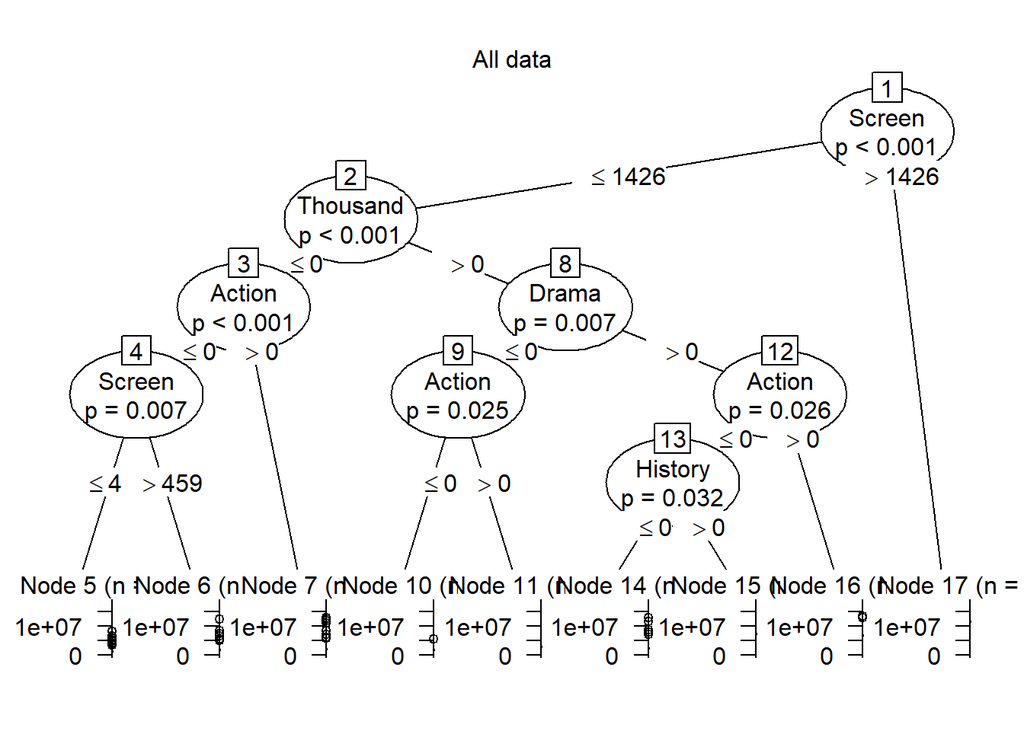

```r
library("party")
t1 <- ctree(Audience~Year+Screen+History+Action+Drama+Horor+Disaster+Comic+Erotic+Crime+Actorpower+Thousand+Factory,data=movie1)
plot(t1, main="All data")
```

## 7-2 Regression tree-2005

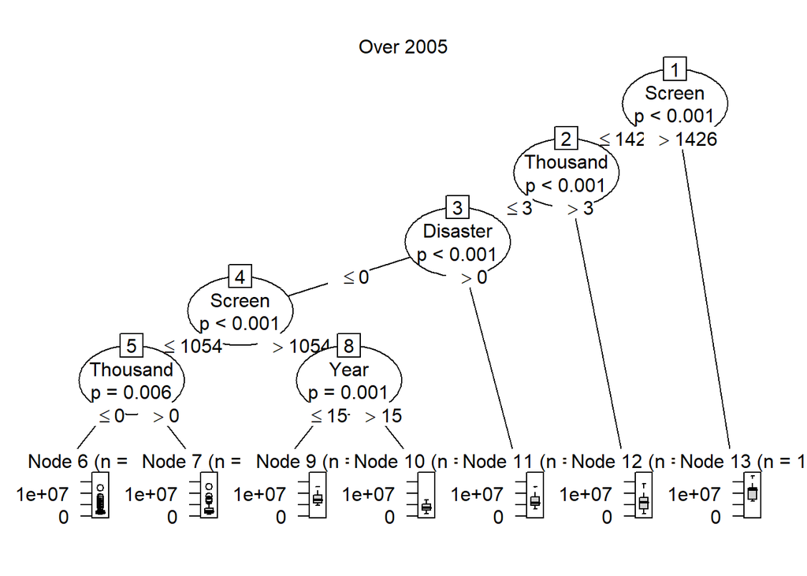

```r
t2 <- ctree(Audience~Year+Screen+History+Action+Drama+Horor+Disaster+Comic+Erotic+Crime+Actorpower+Thousand+Factory,data=movie2)
plot(t2,main="Over 2005")
```

## 7-3 Regression tree-2010

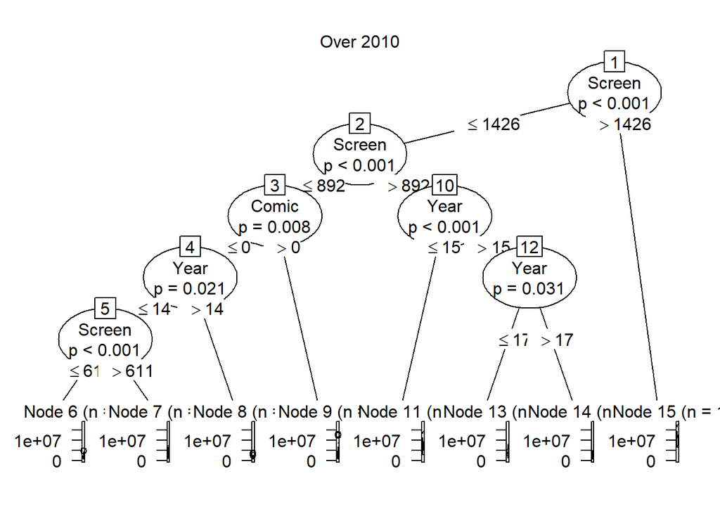

```r
t3 <- ctree(Audience~Year+Screen+History+Action+Drama+Horor+Disaster+Comic+Erotic+Crime+Actorpower+Thousand+Factory,data=movie3)
plot(t3,main="Over 2010")
```